# Week 5: Dimensionality reduction techniques

## Overview of the data and data wrangling

Packages for the session

```r
rm(list=ls())
library(GGally)
library(ggplot2)
library(dplyr)
library(corrplot)
library(tidyr)
```

We read the data and take a look at the summary

```r
human <- read.csv("~/IODS-project/data/human.csv", sep  =",", header = T, row.names = 1)
names(human)
```

```
## [1] "life_exp"               "exp_education"
## [3] "gni"                    "maternal_mortality_rat"
## [5] "adolescent_birth_rat"   "female_parliament"
## [7] "sec_ed_rat"             "lfpr_ratio"
```

```r
summary(human)
```

```
##     life_exp     exp_education        gni         maternal_mortality_rat
##  Min.   :49.00   Min.   : 5.40   Min.   :   581   Min.   :   1.0
##  1st Qu.:66.30   1st Qu.:11.25   1st Qu.:  4198   1st Qu.:  11.5
##  Median :74.20   Median :13.50   Median : 12040   Median :  49.0
##  Mean   :71.65   Mean   :13.18   Mean   : 17628   Mean   : 149.1
##  3rd Qu.:77.25   3rd Qu.:15.20   3rd Qu.: 24512   3rd Qu.: 190.0
##  Max.   :83.50   Max.   :20.20   Max.   :123124   Max.   :1100.0
##  adolescent_birth_rat female_parliament   sec_ed_rat       lfpr_ratio
##  Min.   :  0.60       Min.   : 0.00     Min.   :0.1717   Min.   :0.1857
##  1st Qu.: 12.65       1st Qu.:12.40     1st Qu.:0.7264   1st Qu.:0.5984
##  Median : 33.60       Median :19.30     Median :0.9375   Median :0.7535
##  Mean   : 47.16       Mean   :20.91     Mean   :0.8529   Mean   :0.7074
##  3rd Qu.: 71.95       3rd Qu.:27.95     3rd Qu.:0.9968   3rd Qu.:0.8535
##  Max.   :204.80       Max.   :57.50     Max.   :1.4967   Max.   :1.0380
```

We have 155 observations and 8 variables from OECD’s Human development report. Link to more information: http://hdr.undp.org/en/content/human-development-index-hdi Next we look graphically at the relations

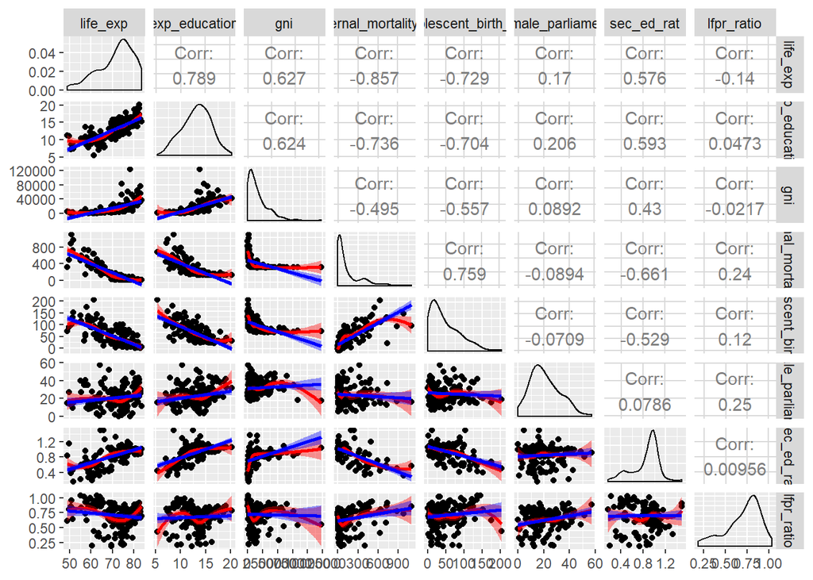

```r
my_fn <- function(data, mapping, ...){
  p <- ggplot(data = data, mapping = mapping) +
    geom_point() +
    geom_smooth(method=loess, fill="red", color="red", ...) +
    geom_smooth(method=lm, fill="blue", color="blue", ...)
  p
}
ggpairs(human, lower = list(continuous = my_fn))
```

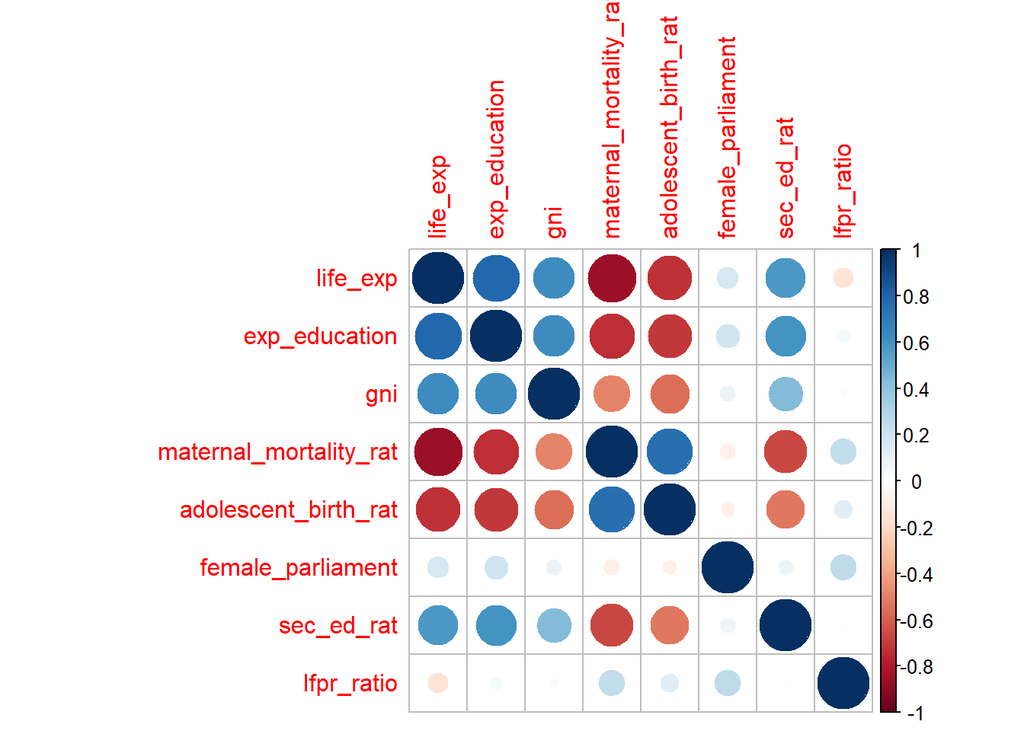

```r
cor(human) %>% corrplot
```

Many of the variables are not perfectly normally distributed and are skewed either to the right or left. There is some obvious (negative) correlations for example maternal mortality ratio and life expectancy.

## Principal component analysis PCA (Not standardized data & standardized data)

We proceed to PCA for the not standardized human data.

```r
pca_human_not_std <- prcomp(human)
sum_pca_human_not_std <- summary(pca_human_not_std)
pca_pr_not_std <- round(100*sum_pca_human_not_std$importance[2, ], digits = 3)
pca_pr_not_std
```

```
##   PC1   PC2   PC3   PC4   PC5   PC6   PC7   PC8
## 99.99  0.01  0.00  0.00  0.00  0.00  0.00  0.00
```

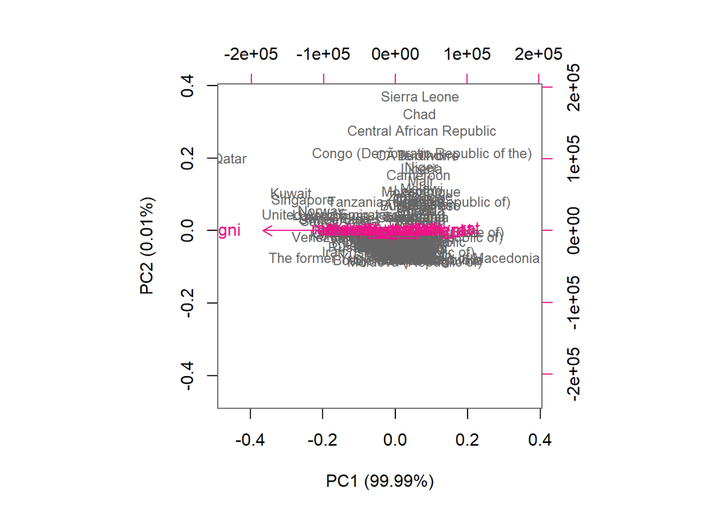

```r
pc_lab_not_std <- paste0(names(pca_pr_not_std), " (", pca_pr_not_std, "%)")
biplot(pca_human_not_std, cex = c(0.8, 1), col = c("grey40", "deeppink2"), xlab = pc_lab_not_std[1], ylab = pc_lab_not_std[2])
```

There is two principal components catching any variance. The first principal component catches 99.99% of the variance.

How do things change when we standardize?

```r
human_std <- scale(human)
pca_human <- prcomp(human_std)
sum_pca_human <- summary(pca_human)
pca_pr <- round(100*sum_pca_human$importance[2, ], digits = 3)
pca_pr
```

```
##    PC1    PC2    PC3    PC4    PC5    PC6    PC7    PC8
## 53.605 16.237  9.571  7.583  5.477  3.595  2.634  1.298
```

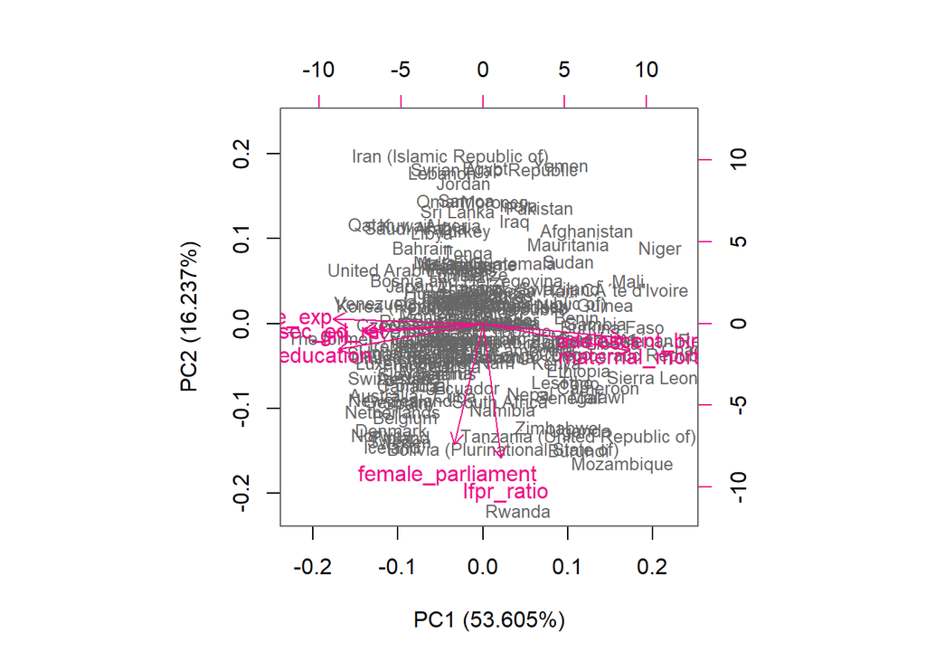

```r
pc_lab <- paste0(names(pca_pr), " (", pca_pr, "%)")

biplot(pca_human, cex = c(0.8, 1), col = c("grey40", "deeppink2"), xlab = pc_lab[1], ylab = pc_lab[2])
```

We see that variance captured changes dramatically when the human data is standardized and for meaningful research it is necessary. Now all eight principal components catch variance.First component catches only 53,6 % now. X-axis is representing PC1 and y-axis is representing PC2. The direction and lenght of arrows represents how increase in each variable affects where the observation will be plotted. The points where countries are is the linear combination of the “arrows”. We can see that the rich countries are on the left side and poorer on the right (PC1). The vertical axis tells about countries equality.

## Tea time

For tea time we need to add factominer library. Let’s read the data.

```r
library(FactoMineR)
tea <- read.table("http://factominer.free.fr/book/tea.csv",header=TRUE,sep=";")
colnames(tea)
```

```
##  [1] "breakfast"         "afternoon.tea"     "evening"
##  [4] "after.lunch"       "after.dinner"      "anytime"
##  [7] "home"              "work"              "tearoom"
## [10] "friends"           "restaurant"        "pub"
## [13] "variety"           "how"               "sugar"
## [16] "format"            "place.of.purchase" "type"
## [19] "sex"               "profession"        "sport"
## [22] "age"               "age_Q"             "frequency"
## [25] "exotic"            "spirituality"      "good.for.health"
## [28] "diuretic"          "friendliness"      "iron.absorption"
## [31] "feminine"          "refined"           "slimming"
## [34] "stimulant"         "relaxant"          "no.effect.health"
```

```r
str(tea)
```

```
## 'data.frame':    300 obs. of  36 variables:
##  $ breakfast        : Factor w/ 2 levels "breakfast","not.breakfast": 1 1 2 2 1 2 1 2 1 1 ...
##  $ afternoon.tea    : Factor w/ 2 levels "afternoon.tea",..: 2 2 1 2 2 2 1 1 1 2 ...
##  $ evening          : Factor w/ 2 levels "evening","not.evening": 2 2 1 2 1 2 2 1 2 1 ...
##  $ after.lunch      : Factor w/ 2 levels "after.lunch",..: 2 2 2 2 2 2 2 2 2 2 ...
##  $ after.dinner     : Factor w/ 2 levels "after.dinner",..: 2 2 1 1 2 1 2 2 2 2 ...
##  $ anytime          : Factor w/ 2 levels "anytime","not.anytime": 2 2 2 2 1 2 2 2 2 2 ...
##  $ home             : Factor w/ 2 levels "home","not.home": 1 1 1 1 1 1 1 1 1 1 ...
##  $ work             : Factor w/ 2 levels "not.work","work": 1 1 2 1 1 1 1 1 1 1 ...
##  $ tearoom          : Factor w/ 2 levels "not.tearoom",..: 1 1 1 1 1 1 1 1 1 2 ...
##  $ friends          : Factor w/ 2 levels "friends","not.friends": 2 2 1 2 2 2 1 2 2 2 ...
##  $ restaurant       : Factor w/ 2 levels "not.restaurant",..: 1 1 2 1 1 1 1 1 1 1 ...
##  $ pub              : Factor w/ 2 levels "not.pub","pub": 1 1 1 1 1 1 1 1 1 1 ...
##  $ variety          : Factor w/ 3 levels "black","flavoured",..: 1 1 2 2 2 2 2 1 2 1 ...
##  $ how              : Factor w/ 4 levels "lemon","milk",..: 3 2 3 3 3 3 3 2 2 3 ...
```

[output cut: 22 more lines]

```r
summary(tea)
```

```
##          breakfast           afternoon.tea        evening
##  breakfast    :144   afternoon.tea  :169   evening    :103
##  not.breakfast:156   Not.afternoon.t:131   not.evening:197
##
##
##
##
##
##           after.lunch            after.dinner        anytime
##  after.lunch    : 44   after.dinner    : 21   anytime    :103
##  not.after.lunch:256   not.after.dinner:279   not.anytime:197
##
##
##
##
##
##        home           work            tearoom           friends
##  home    :291   not.work:213   not.tearoom:242   friends    :196
##  not.home:  9   work    : 87   tearoom    : 58   not.friends:104
##
##
##
##
##
##           restaurant       pub           variety               how
##  not.restaurant:221   not.pub:237   black    : 74   lemon        : 33
##  restaurant    : 79   pub    : 63   flavoured:193   milk         : 63
##                                     green    : 33   nothing.added:195
##                                                     other        :  9
##
##
##
##        sugar              format                  place.of.purchase
##  not.sugar:155   loose       : 36   specialist.shop        : 30
##  sugar    :145   sachet      :170   supermarket            :192
##                  sachet+loose: 94   supermarket+specialist.: 78
##
##
##
##
```

[output cut: 33 more lines]

```
##  not.refined: 85   not.slimming:255   not.stimulant:184
##  refined    :215   slimming    : 45   stimulant    :116
##
##
##
##
##
##          relaxant                    no.effect.health
##  not.relaxant:113   no.effect.health         : 66
##  relaxant    :187   not.without.effect.health:234
##
##
##
##
##
```

We have 300 observations from 36 variables. Next we observe variables graphically. We include only variables: “variety”, “how”, “format”, “sugar”, “place.of.purchase”, “after.lunch” for our visualization to make it clearer.

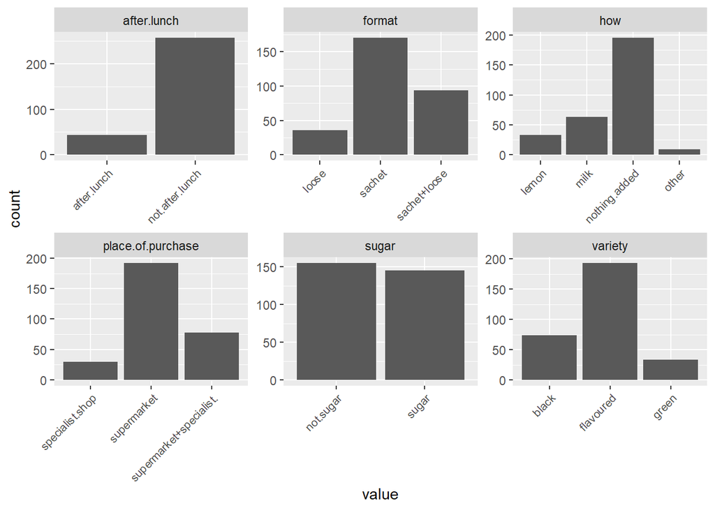

```r
tea_time <- dplyr::select(tea, variety, how, format, sugar, place.of.purchase, after.lunch)
gather(tea_time) %>% ggplot(aes(value)) + facet_wrap("key", scales = "free") + geom_bar() + theme(axis.text.x = element_text(angle = 45, hjust = 1, size = 8))
```

We proceed to do multiple correspondence analysis and visualize it.

```r
# multiple correspondence analysis
mca <- MCA(tea_time, graph = FALSE)

# summary of the model
summary(mca)
```

```
##
## Call:
## MCA(X = tea_time, graph = FALSE)
##
##
## Eigenvalues
##                        Dim.1   Dim.2   Dim.3   Dim.4   Dim.5   Dim.6
## Variance               0.279   0.261   0.219   0.189   0.177   0.156
## % of var.             15.238  14.232  11.964  10.333   9.667   8.519
## Cumulative % of var.  15.238  29.471  41.435  51.768  61.434  69.953
##                        Dim.7   Dim.8   Dim.9  Dim.10  Dim.11
## Variance               0.144   0.141   0.117   0.087   0.062
## % of var.              7.841   7.705   6.392   4.724   3.385
## Cumulative % of var.  77.794  85.500  91.891  96.615 100.000
##
## Individuals (the 10 first)
##                  Dim.1    ctr   cos2    Dim.2    ctr   cos2    Dim.3
## 1             | -0.298  0.106  0.086 | -0.328  0.137  0.105 | -0.327
## 2             | -0.237  0.067  0.036 | -0.136  0.024  0.012 | -0.695
## 3             | -0.369  0.162  0.231 | -0.300  0.115  0.153 | -0.202
## 4             | -0.530  0.335  0.460 | -0.318  0.129  0.166 |  0.211
## 5             | -0.369  0.162  0.231 | -0.300  0.115  0.153 | -0.202
## 6             | -0.369  0.162  0.231 | -0.300  0.115  0.153 | -0.202
## 7             | -0.369  0.162  0.231 | -0.300  0.115  0.153 | -0.202
## 8             | -0.237  0.067  0.036 | -0.136  0.024  0.012 | -0.695
## 9             |  0.143  0.024  0.012 |  0.871  0.969  0.435 | -0.067
## 10            |  0.476  0.271  0.140 |  0.687  0.604  0.291 | -0.650
##                  ctr   cos2
## 1              0.163  0.104 |
## 2              0.735  0.314 |
## 3              0.062  0.069 |
## 4              0.068  0.073 |
## 5              0.062  0.069 |
## 6              0.062  0.069 |
## 7              0.062  0.069 |
## 8              0.735  0.314 |
## 9              0.007  0.003 |
## 10             0.643  0.261 |
##
## Categories (the 10 first)
```

[output cut: 16 more lines]

```
## milk            2.422 |   0.013   0.003   0.000   0.116 |
## nothing.added  -6.164 |  -0.113   0.627   0.024  -2.655 |
## other           5.534 |  -2.524  14.526   0.197  -7.676 |
## loose          -6.482 |   0.257   0.602   0.009   1.640 |
## sachet         -6.941 |  -0.065   0.183   0.006  -1.287 |
## sachet+loose   11.956 |   0.019   0.009   0.000   0.226 |
##
## Categorical variables (eta2)
##                     Dim.1 Dim.2 Dim.3
## variety           | 0.126 0.108 0.410 |
## how               | 0.076 0.190 0.394 |
## format            | 0.708 0.522 0.010 |
## sugar             | 0.065 0.001 0.336 |
## place.of.purchase | 0.702 0.681 0.055 |
## after.lunch       | 0.000 0.064 0.111 |
```

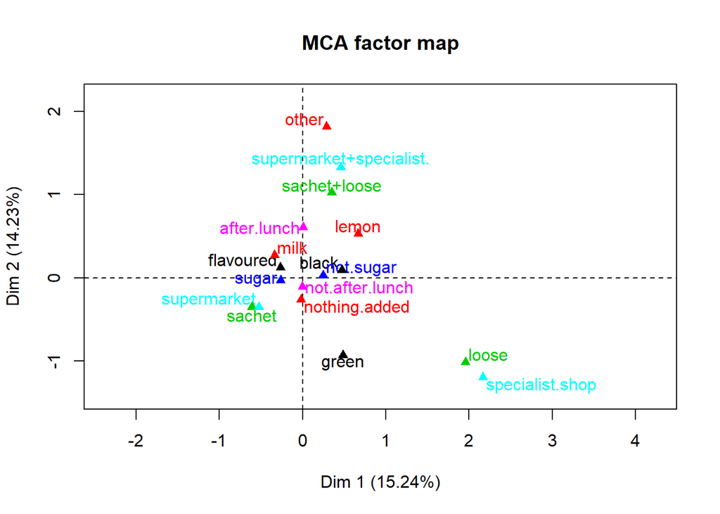

```r
# visualize MCA
plot(mca, invisible=c("ind"), habillage = "quali")
```

Dimensions 1 (15.24 %) and 2 (14.23 %) capture almost 30% of the variance.